# Lecture 5 Scripts and Practice

## Forward geocoding

You can use the tidygeocoder package in R.

The code below is an example of forward geocoding (addresses ⮕ coordinates). By default, geocode() uses Nominatim (a geocoding software package) to perform the task.

```r
# run via Console if not installed before:
# install.packages("tidygeocoder")
library(tidygeocoder)
addresses_df <- data.frame(address = c("60 College St, New Haven, CT"))
geocode(addresses_df, address = address)
```

```
Passing 1 address to the Nominatim single address geocoder
```

```
Query completed in: 1 seconds
```

```
# A tibble: 1 × 3
  address                        lat  long
  <chr>                        <dbl> <dbl>
1 60 College St, New Haven, CT  41.3 -72.9
```

## Forward geocoding

It can process multiple addresses:

```r
# run if not installed before: install.packages("tidygeocoder")
library(tidygeocoder)
addresses_df_v2 <- data.frame(address = c("1600 Pennsylvania Avenue, Washington, DC",
                                       "1313 Disneyland Dr, Anaheim, CA"))
geocode(addresses_df_v2, address = address)
```

```
Passing 2 addresses to the Nominatim single address geocoder
```

```
Query completed in: 2 seconds
```

```
# A tibble: 2 × 3
  address                                    lat   long
  <chr>                                    <dbl>  <dbl>
1 1600 Pennsylvania Avenue, Washington, DC  38.9  -77.0
2 1313 Disneyland Dr, Anaheim, CA           33.8 -118.
```

## Forward geocoding

If you are interested in determining the geographies (e.g., county, tract information), we need to use the census method which leverages the Census API.

```r
# run if not installed before: install.packages("tidygeocoder")
library(tidygeocoder)
addresses_df_v3 <- data.frame(address = c("26 Plympton St, Cambridge, MA"))
results_df <- geocode(addresses_df_v3, address = address, method = "census",
        full_results = TRUE, api_options = list(census_return_type = 'geographies'))
```

```
Passing 1 address to the US Census single address geocoder
```

```
Query completed in: 0.6 seconds
```

```r
# Script you need to run to see county information
results_df$geographies.Counties
```

```
[[1]]
  GEOID     CENTLAT AREAWATER STATE  BASENAME            OID LSADC FUNCSTAT
1 25017 +42.4853699  75225346    25 Middlesex 27590260056194    06        N
     INTPTLAT             NAME OBJECTID      CENTLON COUNTYCC COUNTYNS
1 +42.4817215 Middlesex County     2089 -071.3915833       H4 00606935
    AREALAND     INTPTLON MTFCC COUNTY
1 2118357703 -071.3949160 G4020    017
```

```r
# Script you need to run to see county information
results_df$`geographies.Census Tracts`
```

```
[[1]]
        GEOID     CENTLAT AREAWATER STATE BASENAME            OID LSADC
1 25017353700 +42.3745268         0    25     3537 20790260102279    CT
  FUNCSTAT    INTPTLAT              NAME OBJECTID  TRACT      CENTLON AREALAND
1        S +42.3745268 Census Tract 3537    17676 353700 -071.1122878   532087
      INTPTLON MTFCC COUNTY
1 -071.1122878 G5020    017
```

## Reverse geocoding

```r
reverse_geo(lat = "41.30374", long = "-72.93216")
```

```
Passing 1 coordinate to the Nominatim single coordinate geocoder
```

```
Query completed in: 1 seconds
```

```
# A tibble: 1 × 3
    lat  long address
  <dbl> <dbl> <chr>
1  41.3 -72.9 Laboratory of Epidemiology and Public Health, 60, College Street,…
```

## Practice 1

Using the tidygeocoder package, determine the 5-digit county FIPS or GEOID code for the following address: 9641 W Sunset Blvd, Beverly Hills, CA

```r
addresses_df_v3 <- data.frame(address = c("9641 W Sunset Blvd, Beverly Hills, CA"))
results_df <- geocode(addresses_df_v3, address = address, method = "census",
        full_results = TRUE, api_options = list(census_return_type = 'geographies'))
```

```
Passing 1 address to the US Census single address geocoder
```

```
Query completed in: 0.5 seconds
```

```r
results_df$geographies.Counties
```

```
[[1]]
  GEOID     CENTLAT  AREAWATER STATE    BASENAME             OID LSADC FUNCSTAT
1 06037 +34.1959609 1784898181    06 Los Angeles 275901063468976    06        A
     INTPTLAT               NAME OBJECTID      CENTLON COUNTYCC COUNTYNS
1 +34.1963983 Los Angeles County     1855 -118.2618084       H1 00277283
     AREALAND     INTPTLON MTFCC COUNTY
1 10516093289 -118.2618616 G4020    037
```

## censusapi package: pulling data into R

Suppose we are interesting in county-level population data. According to the ACS 2022 table shell, the variable we need to use is: B01001_001E.

We can use the censusapi package to get census data directly into R.

```r
library(censusapi)
Sys.setenv(CENSUS_KEY="") # put your API key here
population_data <- getCensus(
  name = "acs/acs5", # requests ACS5 data
  vintage = 2022, # requests 2022 data
  vars = c("B01001_001E"), #requested variable
  region = "county:*") #requested geography
head(population_data)
```

```
  state county B01001_001E
1    01    001       58761
2    01    003      233420
3    01    005       24877
4    01    007       22251
5    01    009       59077
6    01    011       10328
```

## Examples of Other Important censusapi calls

An example of asking for multiple variables:

```r
data1 <- getCensus(name = "acs/acs5", vintage = 2019,
                   vars = c("B28002_001E", "B28002_002E"),
                   region = "county:*")
head(data1)
```

```
  state county B28002_001E B28002_002E
1    17    051        7737        5629
2    17    107       10797        8370
3    17    165        9972        7223
4    17    097      246122      221633
5    17    127        5822        3979
6    17    017        5043        3869
```

An example of asking for Connecticut-only county-level data (Note: CT’s FIPS code is 09).

```r
data2 <- getCensus(name = "acs/acs5", vintage = 2019,
                   vars = c("B28002_001E", "B28002_002E"),
                  region = "county:*", regionin = "state:09")
head(data2)
```

```
  state county B28002_001E B28002_002E
1    09    009      330572      276814
2    09    003      350408      295089
3    09    015       44953       37809
4    09    011      107827       93528
5    09    007       66971       58063
6    09    013       55683       49334
```

An example of asking for Missouri-only tract-level data (Note: MO’s FIPS code is 29).

```r
data3 <- getCensus(name = "acs/acs5", vintage = 2019,
                   vars = c("B28002_001E", "B28002_002E"),
                   region = "tract:*", regionin = "state:29")
head(data3)
```

```
  state county  tract B28002_001E B28002_002E
1    29    095 007300        2083        1714
2    29    095 007600         810         511
3    29    095 007900        1467         831
4    29    095 010201         980         700
5    29    095 008300        1002         940
6    29    095 009100        1801        1633
```

## Creating SVI Map for MO

Step 1: Retrieve shapefile needed.

```r
library(tigris)
mo_shape_file <- tracts(state = "MO", year = 2019)
# not required but nice to visualize data
head(mo_shape_file)
```

```
Simple feature collection with 6 features and 12 fields
Geometry type: POLYGON
Dimension:     XY
Bounding box:  xmin: -93.32762 ymin: 37.06259 xmax: -91.09394 ymax: 38.37489
Geodetic CRS:  NAD83
  STATEFP COUNTYFP TRACTCE       GEOID    NAME             NAMELSAD MTFCC
1      29      055  450302 29055450302 4503.02 Census Tract 4503.02 G5020
2      29      055  450102 29055450102 4501.02 Census Tract 4501.02 G5020
3      29      055  450200 29055450200    4502    Census Tract 4502 G5020
4      29      055  450400 29055450400    4504    Census Tract 4504 G5020
5      29      015  460400 29015460400    4604    Census Tract 4604 G5020
6      29      229  490300 29229490300    4903    Census Tract 4903 G5020
  FUNCSTAT     ALAND   AWATER    INTPTLAT     INTPTLON
1        S  59019556    54839 +38.0699995 -091.3834407
2        S 215515312   158937 +38.1505661 -091.1929142
3        S 785265618   714683 +37.9120761 -091.2086380
4        S 518540939   475755 +37.8958096 -091.3892205
5        S 216350354 11553444 +38.3016635 -093.1718555
6        S 335405942   257629 +37.1176895 -092.5083341
                        geometry
1 POLYGON ((-91.42897 38.0501...
2 POLYGON ((-91.31192 38.1507...
3 POLYGON ((-91.3684 38.09352...
4 POLYGON ((-91.52872 37.7942...
5 POLYGON ((-93.32762 38.2696...
6 POLYGON ((-92.68554 37.0748...
```

Step 2: Load MO SVI data into R.

```r
library(tidyverse)
mo_svi_data <- read_csv("https://raw.githubusercontent.com/jmtfeliciano/teachingdata/refs/heads/main/MissouriSVI2019.csv") |>
  mutate(GEOID = as.character(FIPS)) # rename FIPS into GEOID
head(mo_svi_data)
```

```
# A tibble: 6 × 13
     ST STATE    ST_ABBR STCNTY COUNTY       FIPS LOCATION RPL_THEME1 RPL_THEME2
  <dbl> <chr>    <chr>    <dbl> <chr>       <dbl> <chr>         <dbl>      <dbl>
1    29 MISSOURI MO       29189 St. Louis 2.92e10 Census …     0.0123     0.067
2    29 MISSOURI MO       29095 Jackson   2.91e10 Census …     0.0007     0.130
3    29 MISSOURI MO       29095 Jackson   2.91e10 Census …     0.018      0.0252
4    29 MISSOURI MO       29095 Jackson   2.91e10 Census …     0          0.189
5    29 MISSOURI MO       29189 St. Louis 2.92e10 Census …     0.0079     0.219
6    29 MISSOURI MO       29095 Jackson   2.91e10 Census …     0.0346     0.0159
# ℹ 4 more variables: RPL_THEME3 <dbl>, RPL_THEME4 <dbl>, RPL_THEMES <dbl>,
#   GEOID <chr>
```

Step 3: Merge SVI data into shapefile.

```r
mo_shape_file_v2 <- left_join(mo_shape_file, mo_svi_data)
glimpse(mo_shape_file_v2)
```

```
Rows: 1,393
Columns: 25
$ STATEFP    <chr> "29", "29", "29", "29", "29", "29", "29", "29", "29", "29",…
$ COUNTYFP   <chr> "055", "055", "055", "055", "015", "229", "229", "229", "22…
$ TRACTCE    <chr> "450302", "450102", "450200", "450400", "460400", "490300",…
$ GEOID      <chr> "29055450302", "29055450102", "29055450200", "29055450400",…
$ NAME       <chr> "4503.02", "4501.02", "4502", "4504", "4604", "4903", "4904…
$ NAMELSAD   <chr> "Census Tract 4503.02", "Census Tract 4501.02", "Census Tra…
$ MTFCC      <chr> "G5020", "G5020", "G5020", "G5020", "G5020", "G5020", "G502…
$ FUNCSTAT   <chr> "S", "S", "S", "S", "S", "S", "S", "S", "S", "S", "S", "S",…
$ ALAND      <dbl> 59019556, 215515312, 785265618, 518540939, 216350354, 33540…
$ AWATER     <dbl> 54839, 158937, 714683, 475755, 11553444, 257629, 136121, 18…
$ INTPTLAT   <chr> "+38.0699995", "+38.1505661", "+37.9120761", "+37.8958096",…
$ INTPTLON   <chr> "-091.3834407", "-091.1929142", "-091.2086380", "-091.38922…
$ ST         <dbl> 29, 29, 29, 29, 29, 29, 29, 29, 29, 29, 29, 29, 29, 29, 29,…
$ STATE      <chr> "MISSOURI", "MISSOURI", "MISSOURI", "MISSOURI", "MISSOURI",…
$ ST_ABBR    <chr> "MO", "MO", "MO", "MO", "MO", "MO", "MO", "MO", "MO", "MO",…
$ STCNTY     <dbl> 29055, 29055, 29055, 29055, 29015, 29229, 29229, 29229, 292…
$ COUNTY     <chr> "Crawford", "Crawford", "Crawford", "Crawford", "Benton", "…
$ FIPS       <dbl> 29055450302, 29055450102, 29055450200, 29055450400, 2901546…
$ LOCATION   <chr> "Census Tract 4503.02, Crawford County, Missouri", "Census …
$ RPL_THEME1 <dbl> 0.9798, 0.7815, 0.9027, 0.7808, 0.9041, 0.8472, 0.8594, 0.7…
$ RPL_THEME2 <dbl> 0.9114, 0.9272, 0.3509, 0.9063, 0.5274, 0.9568, 0.9856, 0.6…
$ RPL_THEME3 <dbl> 0.6614, 0.3105, 0.0375, 0.0879, 0.0187, 0.0468, 0.4517, 0.0…
$ RPL_THEME4 <dbl> 0.8271, 0.7082, 0.5317, 0.6376, 0.2305, 0.8170, 0.8847, 0.3…
$ RPL_THEMES <dbl> 0.9690, 0.7952, 0.5537, 0.7123, 0.4852, 0.8147, 0.9466, 0.4…
$ geometry   <POLYGON [°]> POLYGON ((-91.42897 38.0501..., POLYGON ((-91.31192…
```

Step 4: Plot map (Note: RPL_THEMES is the SVI variable).

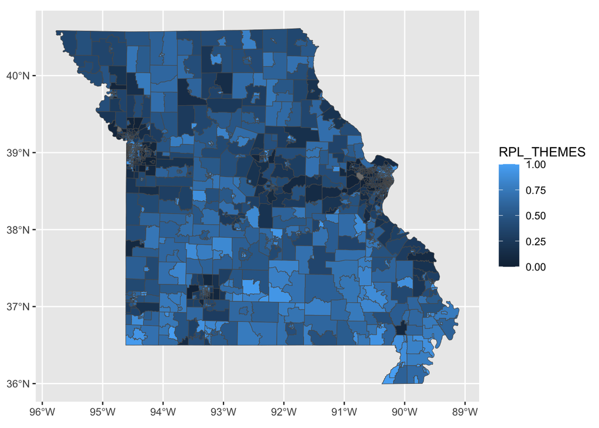

```r
# RPL_THEMES IS THE VARIABLE WE WANT TO RENDER
ggplot(data = mo_shape_file_v2,
       aes(fill = RPL_THEMES)) +
  geom_sf()
```

## Generating Map

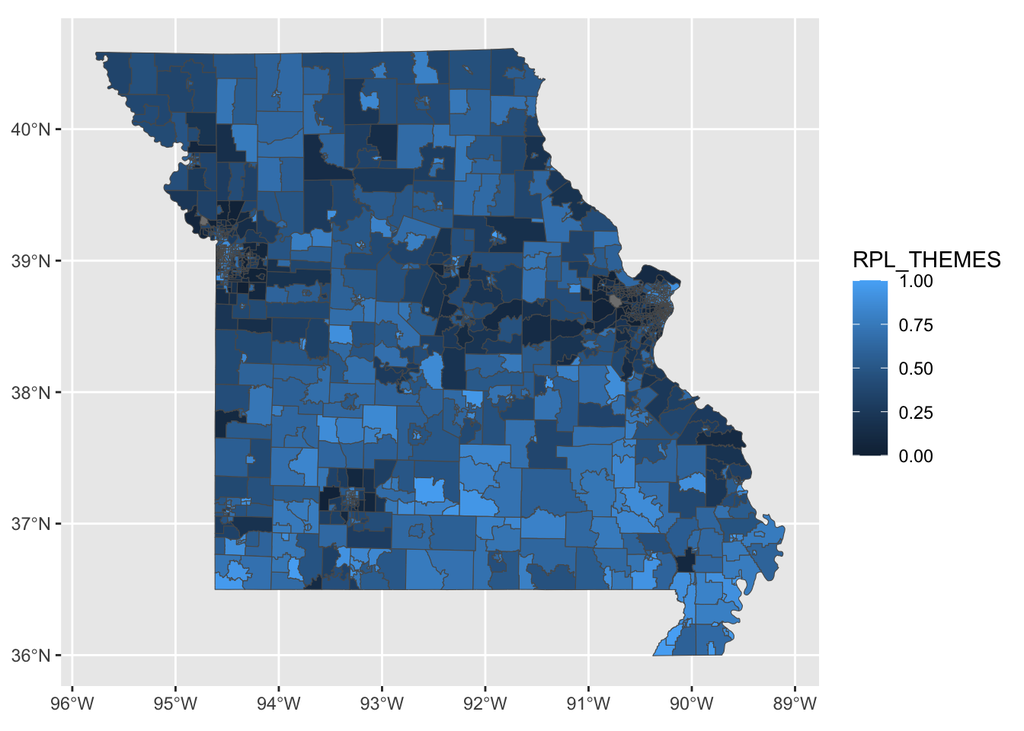

```r
ggplot(data = mo_shape_file_v2,
       aes(fill = RPL_THEMES)) +
  geom_sf()
```

## Further Customizations

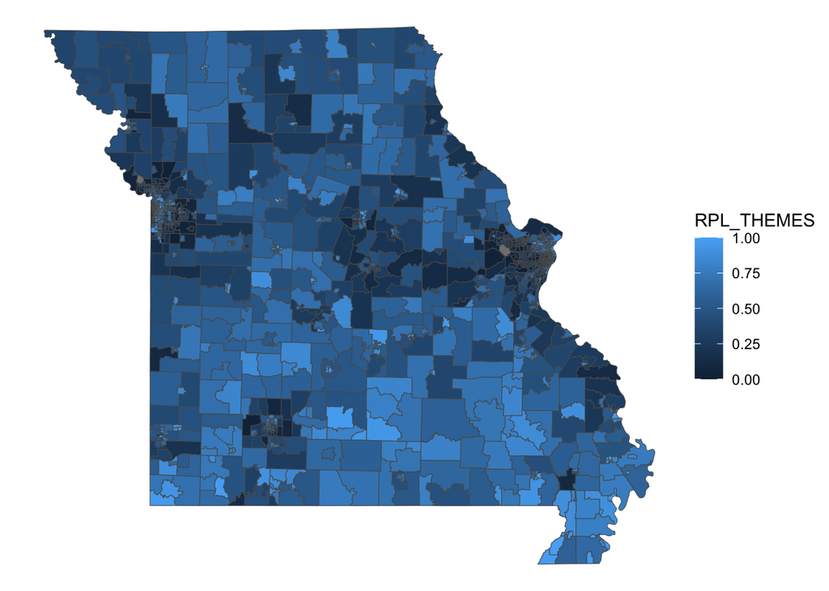

```r
# Added theme_void()
# to remove grid and grey background
ggplot(data = mo_shape_file_v2,
       aes(fill = RPL_THEMES)) +
  geom_sf() +
  theme_void()
```

## Further Customizations Part 2

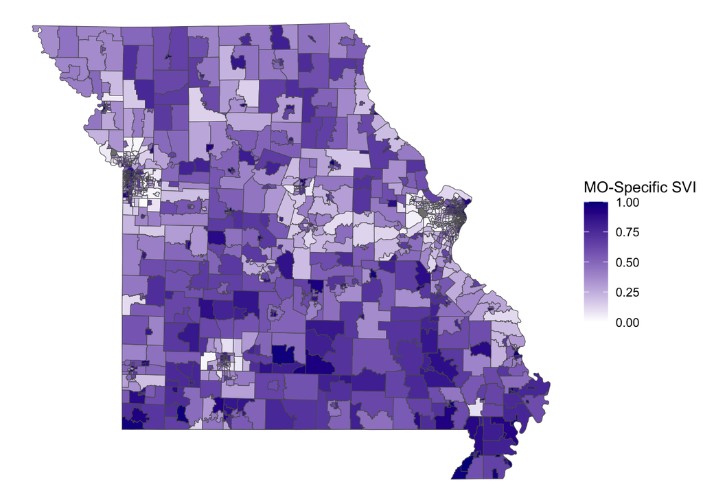

```r
# Further customizes labels and color gradient
ggplot(data = mo_shape_file_v2,
       aes(fill = RPL_THEMES)) +
  geom_sf() +
  theme_void() +
  scale_fill_gradient(low="white",
                      high="darkblue") +
  labs(fill='MO-Specific SVI')
```

## Practice 2

Our joint-task: Create a VA county-level map using counties() using CDC data for 2023-03-03. Create visualization for **covid_cases_per_100k** variable specifically.

**Step 1:** As a class, let us create a va_shape_file R object using counties() for Virginia only and for year 2023.

```r
# Our code here below
va_shape_file <- counties(state = "VA", year = 2023)
head(va_shape_file)
```

```
Simple feature collection with 6 features and 18 fields
Geometry type: MULTIPOLYGON
Dimension:     XY
Bounding box:  xmin: -80.61585 ymin: 36.94445 xmax: -76.13494 ymax: 38.59258
Geodetic CRS:  NAD83
   STATEFP COUNTYFP COUNTYNS GEOID        GEOIDFQ       NAME          NAMELSAD
28      51      775 01789074 51775 0500000US51775      Salem        Salem city
29      51      121 01674630 51121 0500000US51121 Montgomery Montgomery County
37      51      735 01498436 51735 0500000US51735   Poquoson     Poquoson city
40      51      095 01480135 51095 0500000US51095 James City James City County
50      51      179 01480173 51179 0500000US51179   Stafford   Stafford County
98      51      181 01480174 51181 0500000US51181      Surry      Surry County
   LSAD CLASSFP MTFCC CSAFP CBSAFP METDIVFP FUNCSTAT      ALAND    AWATER
28   25      C7 G4020  <NA>  40220     <NA>        F   37593968    275156
29   06      H1 G4020  <NA>  13980     <NA>        A 1001929083   6282286
37   25      C7 G4020   545  47260     <NA>        F   39773690 163429842
40   06      H1 G4020   545  47260     <NA>        A  368550685  95239463
50   06      H1 G4020   548  47900    11694        A  697237751  28087427
98   06      H1 G4020   545  47260     <NA>        A  722475752  81216905
      INTPTLAT     INTPTLON                       geometry
28 +37.2853329 -080.0552407 MULTIPOLYGON (((-80.12049 3...
29 +37.1755376 -080.3877942 MULTIPOLYGON (((-80.53306 3...
37 +37.1283599 -076.3035337 MULTIPOLYGON (((-76.41356 3...
40 +37.3248367 -076.7778878 MULTIPOLYGON (((-76.73855 3...
50 +38.4230836 -077.4580475 MULTIPOLYGON (((-77.56087 3...
98 +37.1197611 -076.8801717 MULTIPOLYGON (((-76.93366 3...
```

**Step 2:** Eventually create a virginia 2023 data frame (call it virginia_cases_df) from covid_cases_df that we will eventually left_join into the shapefile

```r
# covid_cases_df is CDC data for the entire country
covid_cases_df <- read_csv("https://raw.githubusercontent.com/jmtfeliciano/teachingdata/refs/heads/main/cdc_covid_county_data_20230303.csv")
head(covid_cases_df)
```

```
# A tibble: 6 × 12
  county              county_fips state county_population health_service_area_…¹
  <chr>               <chr>       <chr>             <dbl>                  <dbl>
1 American Samoa      60000       Amer…             47392                    901
2 Guam                66000       Guam             168489                    902
3 Commonwealth of th… 69000       Comm…             51851                    903
4 United States Virg… 78000       Unit…            106290                    905
5 Autauga County      01001       Alab…             55869                    171
6 Baldwin County      01003       Alab…            223234                    161
# ℹ abbreviated name: ¹health_service_area_number
# ℹ 7 more variables: health_service_area <chr>,
#   health_service_area_population <dbl>,
#   covid_inpatient_bed_utilization <dbl>,
#   covid_hospital_admissions_per_100k <dbl>, covid_cases_per_100k <dbl>,
#   `covid-19_community_level` <chr>, date_updated <date>
```

```r
# Our code here below
virginia_cases_df <- covid_cases_df |>
  filter(state == "Virginia") |>
  rename(GEOID = county_fips)
# could have also ran mutate(GEOID = as.character(county_fips))

head(virginia_cases_df)
```

```
# A tibble: 6 × 12
  county            GEOID state    county_population health_service_area_number
  <chr>             <chr> <chr>                <dbl>                      <dbl>
1 Accomack County   51001 Virginia             32316                        137
2 Albemarle County  51003 Virginia            109330                         99
3 Alleghany County  51005 Virginia             14860                         30
4 Amelia County     51007 Virginia             13145                         33
5 Amherst County    51009 Virginia             31605                         14
6 Appomattox County 51011 Virginia             15911                         14
# ℹ 7 more variables: health_service_area <chr>,
#   health_service_area_population <dbl>,
#   covid_inpatient_bed_utilization <dbl>,
#   covid_hospital_admissions_per_100k <dbl>, covid_cases_per_100k <dbl>,
#   `covid-19_community_level` <chr>, date_updated <date>
```

**Step 3: left join data we want to render into a map into the shapefile to create desired shapefile**

```r
# Our code here below
va_shape_file_v2 <- left_join(va_shape_file, virginia_cases_df)
head(va_shape_file_v2)
```

```
Simple feature collection with 6 features and 29 fields
Geometry type: MULTIPOLYGON
Dimension:     XY
Bounding box:  xmin: -80.61585 ymin: 36.94445 xmax: -76.13494 ymax: 38.59258
Geodetic CRS:  NAD83
  STATEFP COUNTYFP COUNTYNS GEOID        GEOIDFQ       NAME          NAMELSAD
1      51      775 01789074 51775 0500000US51775      Salem        Salem city
2      51      121 01674630 51121 0500000US51121 Montgomery Montgomery County
3      51      735 01498436 51735 0500000US51735   Poquoson     Poquoson city
4      51      095 01480135 51095 0500000US51095 James City James City County
5      51      179 01480173 51179 0500000US51179   Stafford   Stafford County
6      51      181 01480174 51181 0500000US51181      Surry      Surry County
  LSAD CLASSFP MTFCC CSAFP CBSAFP METDIVFP FUNCSTAT      ALAND    AWATER
1   25      C7 G4020  <NA>  40220     <NA>        F   37593968    275156
2   06      H1 G4020  <NA>  13980     <NA>        A 1001929083   6282286
```

[output cut: 39 more lines]

**Step 4: Render the VA map!**

Use desired shapefile to render map

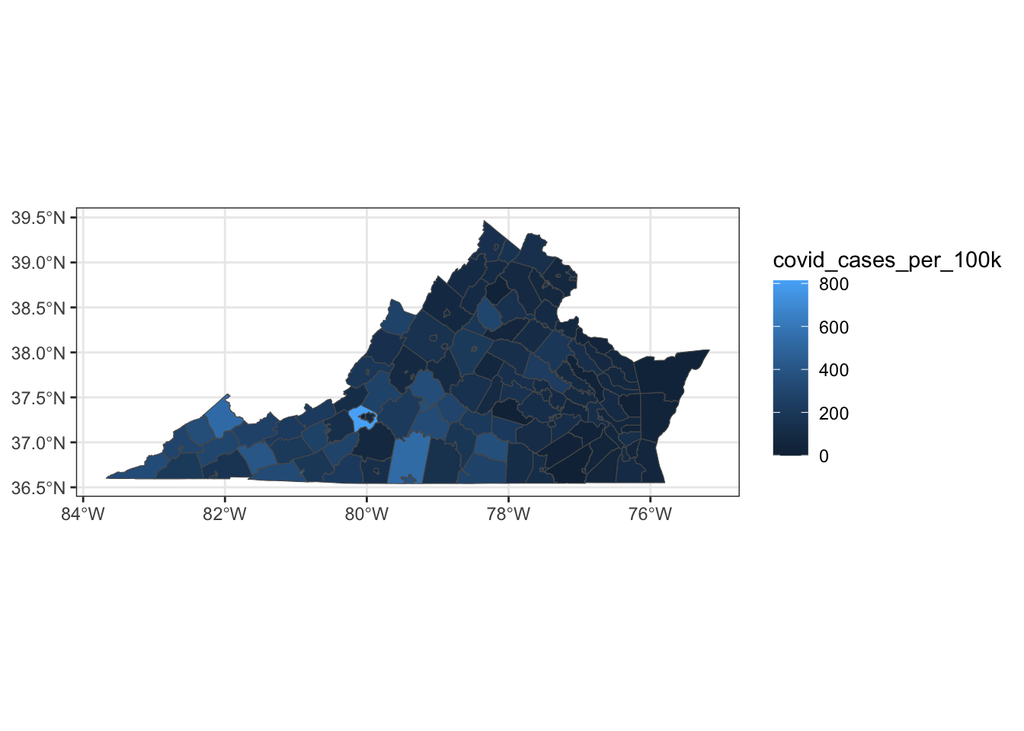

```r
# Our code here below
ggplot(va_shape_file_v2, aes(fill = covid_cases_per_100k)) +
  geom_sf() +
  theme_bw()
```

## tidycensus package and census data

tidycensus is an R package that allows users to interface with a select number of the US Census Bureau’s data APIs and return data frames.

If you want to map ACS-related data, the tidycensus package is the most convenient way to go. One of the advantages of using tidycensus is it has the option to return not just the requested variable(s) but also the corresponding shapefile needed. If your goal is to visualize Census data via a map, tidycensus is the package to use.

Before going further, load the tidycensus package:

```r
# run install.packages("tidycensus") if not installed
library(tidycensus)
```

## tidycensus package and census data.

```r
variable_list_2022 <- load_variables(2022, "acs5", cache = TRUE)
nrow(variable_list_2022)
```

```
[1] 28152
```

```r
head(variable_list_2022)
```

```
# A tibble: 6 × 4
  name        label                                   concept          geography
  <chr>       <chr>                                   <chr>            <chr>
1 B01001A_001 Estimate!!Total:                        Sex by Age (Whi… tract
2 B01001A_002 Estimate!!Total:!!Male:                 Sex by Age (Whi… tract
3 B01001A_003 Estimate!!Total:!!Male:!!Under 5 years  Sex by Age (Whi… tract
4 B01001A_004 Estimate!!Total:!!Male:!!5 to 9 years   Sex by Age (Whi… tract
5 B01001A_005 Estimate!!Total:!!Male:!!10 to 14 years Sex by Age (Whi… tract
6 B01001A_006 Estimate!!Total:!!Male:!!15 to 17 years Sex by Age (Whi… tract
```

## tidycensus package and census data

Advanced recipe: using basic text mining skills in R to find tables related to medicare.

```r
variable_list_2022 |>
  filter(str_detect(concept, regex("medicare", ignore_case = TRUE))) |>
  relocate(concept) # relocate() moves concept into the first column
```

```
# A tibble: 24 × 4
   concept                         name        label                   geography
   <chr>                           <chr>       <chr>                   <chr>
 1 Allocation of Medicare Coverage B992706_001 Estimate!!Total:        tract
 2 Allocation of Medicare Coverage B992706_002 Estimate!!Total:!!Allo… tract
 3 Allocation of Medicare Coverage B992706_003 Estimate!!Total:!!Not … tract
 4 Medicare Coverage by Sex by Age C27006_001  Estimate!!Total:        tract
 5 Medicare Coverage by Sex by Age C27006_002  Estimate!!Total:!!Male: tract
 6 Medicare Coverage by Sex by Age C27006_003  Estimate!!Total:!!Male… tract
 7 Medicare Coverage by Sex by Age C27006_004  Estimate!!Total:!!Male… tract
 8 Medicare Coverage by Sex by Age C27006_005  Estimate!!Total:!!Male… tract
 9 Medicare Coverage by Sex by Age C27006_006  Estimate!!Total:!!Male… tract
10 Medicare Coverage by Sex by Age C27006_007  Estimate!!Total:!!Male… tract
# ℹ 14 more rows
```

## tidycensus package

Task: Suppose we want to map the median % of household income spent on rent for each state using variable B25071_001.

NOTE: when we looked at the table shells, we added ‘E’ at the end of the variable name when using the censusapi package. For tidycensus, it is not required.

```r
library(tidycensus)
census_api_key("YOUR CENSUS API KEY HERE")
shapefile_with_data <- get_acs(
  geography = "state",
  variables = "B25071_001",
  year = 2019,
  survey = "acs5",
  geometry = TRUE,
  shift_geo = TRUE
)
```

```
To install your API key for use in future sessions, run this function with `install = TRUE`.
```

```
Using feature geometry obtained from the albersusa package
```

```
Please note: Alaska and Hawaii are being shifted and are not to scale.
```

```
old-style crs object detected; please recreate object with a recent sf::st_crs()
```

## Rendering the map

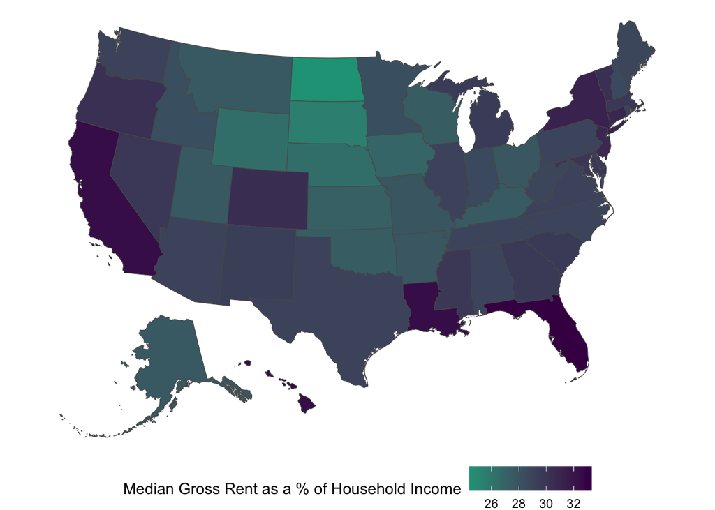

```r
ggplot(data = shapefile_with_data,
       aes(fill = estimate)) +
  geom_sf() +
  theme_void() +
  labs(fill='Median Gross Rent as a % of Household Income') +
  scale_fill_gradient(low="#1fa187",
                      high="#440154") +
  theme(legend.position="bottom")
```

## Rendering the map: Example 2 (Full Template)

```r
library(tidycensus)
library(tidyverse)
census_api_key("YOUR CENSUS API KEY HERE")
ct_shapefile_with_data <- get_acs(
  geography = "county",
  state = "CT",
  variables = "B25071_001",
  year = 2019,
  survey = "acs5",
  geometry = TRUE
  # shift_geo is not needed if you're not mapping entire US
)
ggplot(data = ct_shapefile_with_data,
       aes(fill = estimate)) +
  geom_sf() +
  theme_void() +
  labs(fill='Median Gross Rent as a % of Household Income') +
  scale_fill_gradient(low="white",
                      high="black")
```

```
To install your API key for use in future sessions, run this function with `install = TRUE`.
```

```
Downloading feature geometry from the Census website.  To cache shapefiles for use in future sessions, set `options(tigris_use_cache = TRUE)`.
```

[figure not shown]

## Other functions from tidycensus

`get_estimates()` can give you detailed information about population characteristics. In your own time, try changing the value of `product` to the following: “components”, “population”, or characteristics”.

```r
get_estimates(geography = "state", product = "components", vintage = 2023)
```

```
Using the Vintage 2023 Population Estimates
```

```
# A tibble: 676 × 5
   GEOID NAME    variable          year     value
   <chr> <chr>   <chr>            <int>     <dbl>
 1 01    Alabama BIRTHS            2023 58251
 2 01    Alabama DEATHS            2023 59813
 3 01    Alabama NATURALCHG        2023 -1562
 4 01    Alabama INTERNATIONALMIG  2023  5384
 5 01    Alabama DOMESTICMIG       2023 30744
 6 01    Alabama NETMIG            2023 36128
 7 01    Alabama RESIDUAL          2023    -1
 8 01    Alabama RBIRTH            2023    11.4
 9 01    Alabama RDEATH            2023    11.7
10 01    Alabama RNATURALCHG       2023    -0.307
# ℹ 666 more rows
```

## Other functions from tidycensus

`get_flows()` provides detailed migration flow data (if available).

```r
get_flows(
  geography = "county",
  state = "NY",
  county = "New York",
  year = 2019
)
```

```
# A tibble: 2,019 × 7
   GEOID1 GEOID2 FULL1_NAME                FULL2_NAME    variable estimate   moe
   <chr>  <chr>  <chr>                     <chr>         <chr>       <dbl> <dbl>
 1 36061  <NA>   New York County, New York Africa        MOVEDIN       468   182
 2 36061  <NA>   New York County, New York Africa        MOVEDOUT       NA    NA
 3 36061  <NA>   New York County, New York Africa        MOVEDNET       NA    NA
 4 36061  <NA>   New York County, New York Asia          MOVEDIN      9911  1039
 5 36061  <NA>   New York County, New York Asia          MOVEDOUT       NA    NA
 6 36061  <NA>   New York County, New York Asia          MOVEDNET       NA    NA
 7 36061  <NA>   New York County, New York Central Amer… MOVEDIN      1553   857
 8 36061  <NA>   New York County, New York Central Amer… MOVEDOUT       NA    NA
 9 36061  <NA>   New York County, New York Central Amer… MOVEDNET       NA    NA
10 36061  <NA>   New York County, New York Caribbean     MOVEDIN      2783   712
# ℹ 2,009 more rows
```

## Post-class exercise ideas

Use tidycensus to create other maps.

Use the tigris package with outside data you want to create a map for, and create a map of your own choosing!